# Venice Market Report

## Demand and Activity

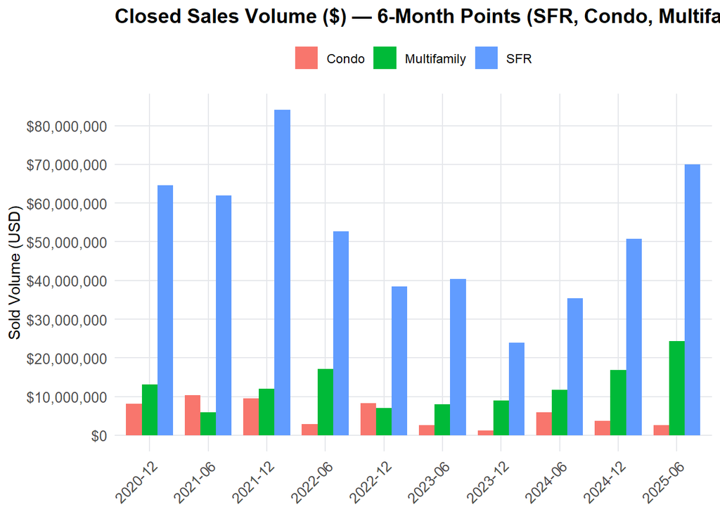

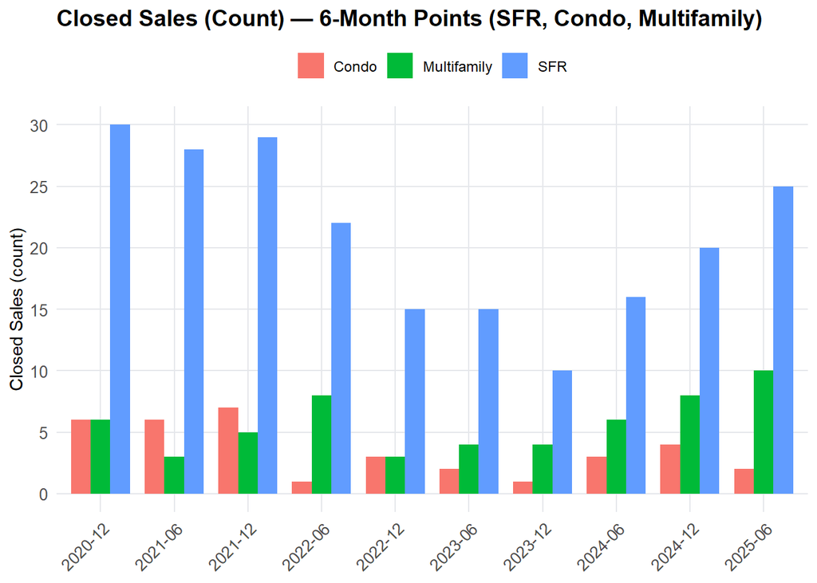

The above two charts show market volume, by dollar amount and sale count. From the above two charts we can see that the market is dominated by single family homes. While there was a dip in activity in 2023, the market began to pick up again in mid 2024.

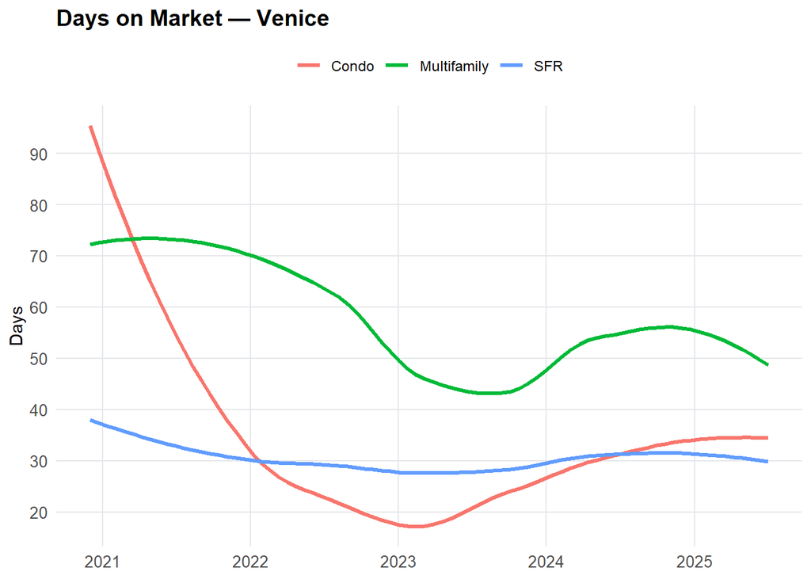

The above graph, showing median days-on-market by asset type, is a good indicator of demand. The longer it takes to sell a home - the lower the demand, and the more power buyers have. In the case of Venice, we can observe a small rise in median DOM during 2024, and a small decline in 2025, signifying a moderate market with increased demand. Coupled with the increase in market activity from the previous section, market power appears to be shifting towards sellers.

### Map: Price Pin Map

[interactive chart not shown]

The above map shows sales in the last 2 year by price point and location. As can be expected, concentration of high value sales can be observed in the Venice Canals, but we can also observe some high value sales around Penmar, and East of Lincoln/North of Venice blvd (especially on Palms blvd).

### Heatmap: Days-On-Market

[interactive chart not shown]

### Map: Asset Type Pin Map

[interactive chart not shown]

The above pin map shows sales by asset type around Venice. We can observe that single family homes are over represented east of Lincoln, whereas multifamily units dominate closer to the ocean. Condos are somewhat sprinkled around, but are more prevalent west of Lincoln.

The heatmap shows locations with quick sale activity - the redder the mark, the faster it sells.